# Activity monitoring data, (Assigment week 2, Reproducible Research course)

## 1. Code for reading in the dataset and/or processing the data

First of all we indicate where the file is, (we have decomprissed previously that file).

```r
setwd("/Users/purificacionvelascomontes/Documents/Personal/Cursos/Coursera_Data_Science/Reproducible_Research_(5)/Week_2/Assignment")
archivo_entrada <- read.csv("activity.csv")
```

We change the format of date field to date format, for next tasks.

```r
archivo_entrada_date <- archivo_entrada
archivo_entrada_date$date <- as.Date(archivo_entrada_date$date, format = "%Y-%m-%d")
```

## 2. Histogram of the total number of steps taken each day

For this task we are going to need the libraries ggplot and dplyr.

```r
library(dplyr)
```

```r
library(ggplot2)
```

We calculate the total number of steps, and we remove the NA values.

```r
steps_per_day <-
  archivo_entrada %>%
  group_by(date) %>%
  summarize(number_steps = sum(steps, na.rm = TRUE))
```

We add a new column to “archivo_entrada” data frame (which is a copy of “date” column), in date format.

```r
steps_date <- as.Date(archivo_entrada$date, format = "%Y-%m-%d")
archivo_entrada$date_date <- steps_date
steps_per_day_date <- steps_per_day
```

We are going to draw the histogram; (with the next sentence, we do in axis **X** we see only some dates with correct format).

```r
steps_per_day_date$date <- as.Date(steps_per_day_date$date, format = "%Y-%m-%d")
```

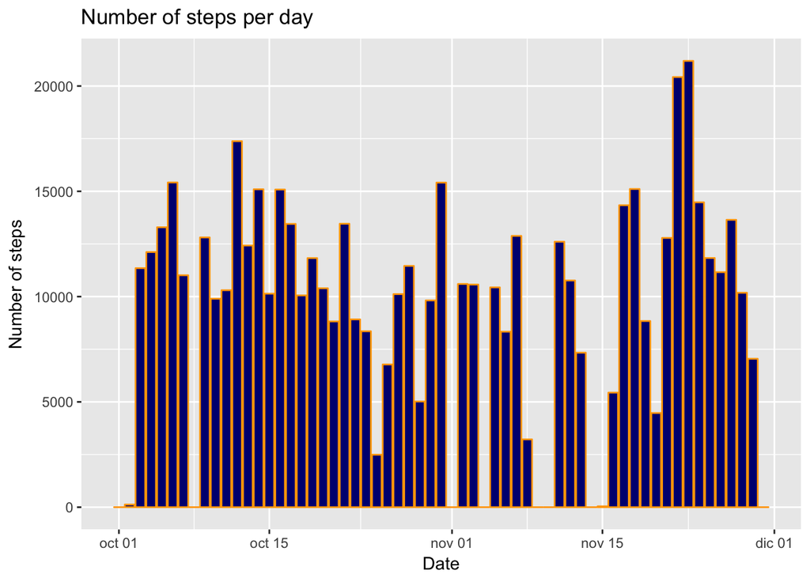

```r
ggplot(data = steps_per_day_date, fill = "blue") +
  geom_bar(mapping = aes(x = date, y = number_steps), stat = "identity", col = c("orange"), fill = c("navy")) +
  xlab("Date") + ylab("Number of steps") + labs(title = "Number of steps per day")
```

## 3. Mean and median number of steps taken each day

We can see the mean and median for all the days.

```r
mean_overall <- mean(steps_per_day$number_steps)
mean_overall
```

```
## [1] 9354.23
```

```r
median(steps_per_day$number_steps)
```

```
## [1] 10395
```

```r
mean_per_day <-
  archivo_entrada %>%
  group_by(date) %>%
  filter(!is.na(steps)) %>%
  summarize(mean_steps = sum(steps)/mean_overall)

median_per_day <-
  archivo_entrada %>%
  group_by(date) %>%
  filter(!is.na(steps)) %>%
  summarize(median_steps = sum(steps)/2)
```

```r
mean_per_day
```

```
## # A tibble: 53 x 2
##    date       mean_steps
##    <fct>           <dbl>
##  1 2012-10-02     0.0135
##  2 2012-10-03     1.21
##  3 2012-10-04     1.30
##  4 2012-10-05     1.42
##  5 2012-10-06     1.65
##  6 2012-10-07     1.18
##  7 2012-10-09     1.37
##  8 2012-10-10     1.06
##  9 2012-10-11     1.10
## 10 2012-10-12     1.86
## # ... with 43 more rows
```

```r
median_per_day
```

```
## # A tibble: 53 x 2
##    date       median_steps
##    <fct>             <dbl>
##  1 2012-10-02         63.0
##  2 2012-10-03       5676.
##  3 2012-10-04       6058.
##  4 2012-10-05       6647.
##  5 2012-10-06       7710.
##  6 2012-10-07       5508.
##  7 2012-10-09       6406.
##  8 2012-10-10       4950.
##  9 2012-10-11       5152.
## 10 2012-10-12       8691.
## # ... with 43 more rows
```

## 4. Time series plot of the average number of steps taken

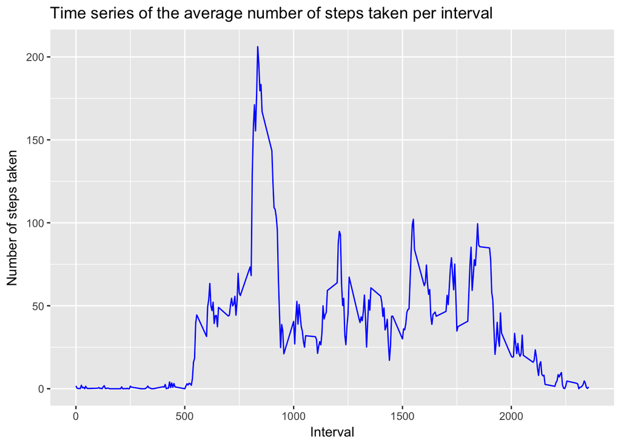

```r
mean_per_day_interval <-
  archivo_entrada %>%
  group_by(interval) %>%
  summarize(avrg_steps = mean(steps, na.rm = TRUE))

ggplot(mean_per_day_interval, aes(interval, avrg_steps)) +
  geom_line(color= "blue") +
  xlab("Interval") + ylab("Number of steps taken") +
  labs(title = "Time series of the average number of steps taken per interval")
```

## 5. The 5-minute interval that, on average, contains the maximum number of steps.

```r
max_number_of_steps <- max(mean_per_day_interval$avrg_steps)
max_row <- mean_per_day_interval[which(mean_per_day_interval$avrg_steps == max_number_of_steps),]
max_interval <- max_row$interval
max_interval
```

```
## [1] 835
```

## 6. Code to describe and show a strategy for imputing missing data.

1. Total number of missing values in the dataset The steps is the unique field that has NA values.

```r
sum(is.na(archivo_entrada$steps))
```

```
## [1] 2304
```

2. Strategy for filling in all of the missing values in the dataset. My strategy is to use the mean steps per interval to filling the missing values.  
   First, we copy the original data frame.

```r
archivo_entrada_filled <- archivo_entrada
```

We create a function to fill the NA values.

```r
mean_steps_per_interval <- function(p_interval) {
  tmp <- mean_per_day_interval[mean_per_day_interval$interval == p_interval,]
  return(tmp$avrg_steps)
}
```

And we use a *for* loop to read the data frame and insert the values.

```r
for(i in 1:nrow(archivo_entrada_filled)) {
  if(is.na(archivo_entrada_filled[i,"steps"])) {
    m_interval <- archivo_entrada_filled[i,"interval"]
    tmp <- mean_steps_per_interval(m_interval)
    archivo_entrada_filled[i,"steps"] <- tmp
  }
}
```

## 7. Histogram of the total number of steps taken each day after missing values are imputed.

```r
steps_per_day_filled <-
  archivo_entrada_filled %>%
  group_by(date) %>%
  summarize(number_steps = sum(steps))
```

```r
steps_per_day_filled_date <- steps_per_day_filled
```

With this, we can see dates with correct format.

```r
steps_per_day_filled_date$date <- as.Date(steps_per_day_filled_date$date, format = "%Y-%m-%d")
```

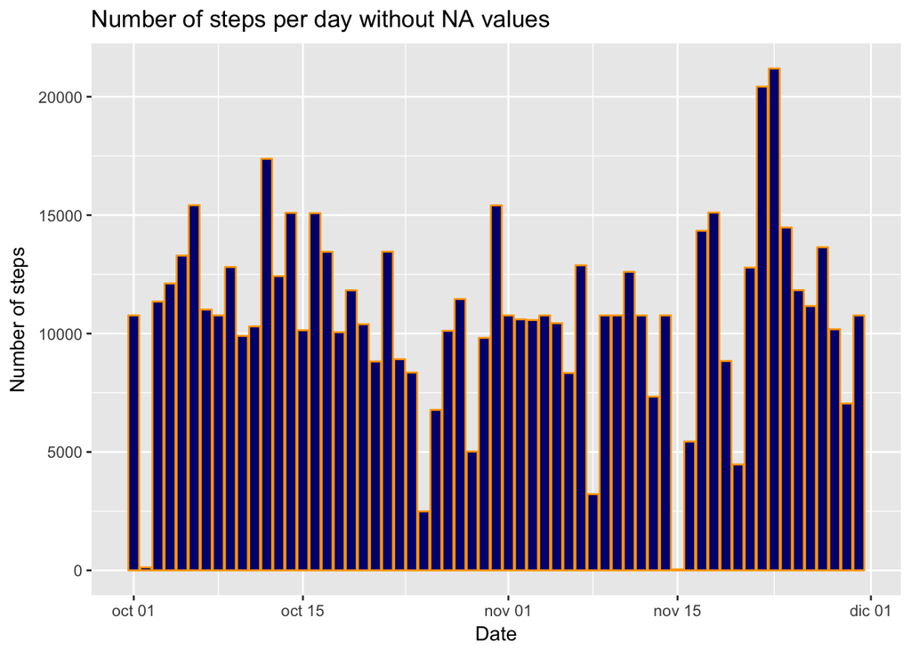

```r
ggplot(data = steps_per_day_filled_date, fill = "blue") +
  geom_bar(mapping = aes(x = date, y = number_steps), stat = "identity", col = c("orange"), fill = c("navy")) +
  xlab("Date") + ylab("Number of steps") + labs(title = "Number of steps per day without NA values")
```

# Mean and median

```r
mean(steps_per_day_filled$number_steps)
```

```
## [1] 10766.19
```

```r
median(steps_per_day_filled$number_steps)
```

```
## [1] 10766.19
```

We are going to create a function to indicate if days are weekdays or weekend.  
(My system language is Spanish, because I am from Spain; for that the days of week are in Spanish).

```r
type_of_day <- function(p_day) {
  day <- weekdays(p_day)
  if (day %in% c("lunes", "martes", "miércoles", "jueves", "viernes"))
    return("weekday")
  else if (day %in% c("sábado", "domingo"))
    return("weekend")
  else
    stop("invalid date")
}
```

We filled the field with the type of the day.

```r
archivo_entrada_filled$day <- sapply(archivo_entrada_filled$date_date, FUN = type_of_day)
```

And we are going to draw the plot using Lattice system.

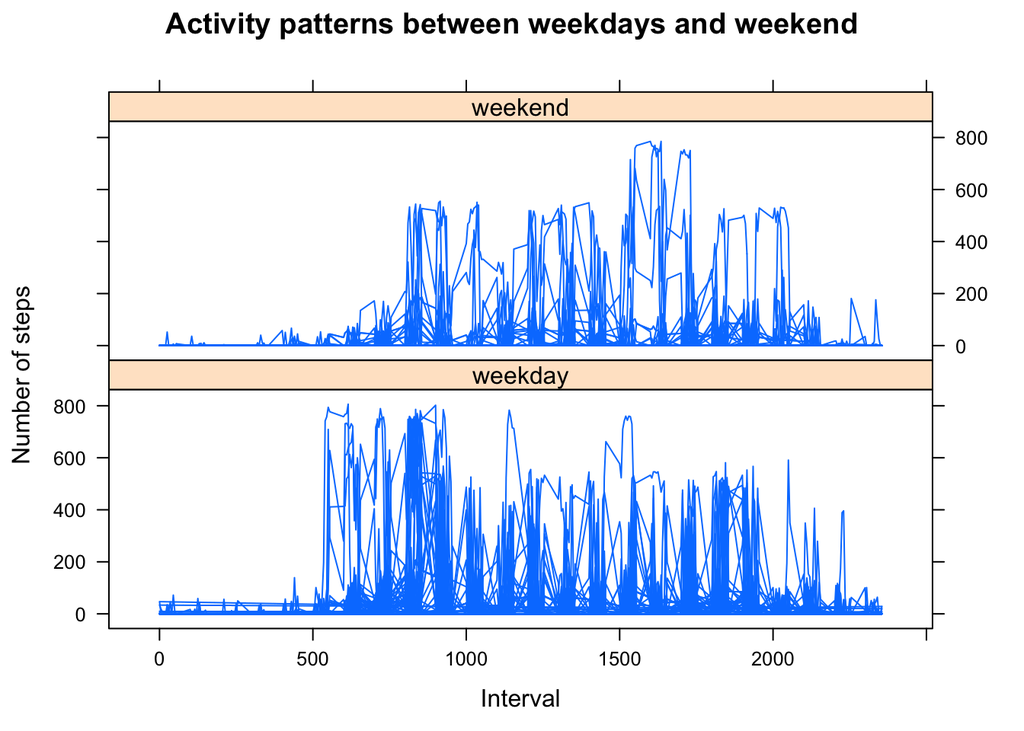

```r
library(lattice)
transform_data <- transform(archivo_entrada_filled, day = factor(day))
xyplot(steps ~ interval | day, data = transform_data, type = "l",
       main = "Activity patterns between weekdays and weekend",
       xlab = "Interval",
       ylab = "Number of steps",
       layout = c(1,2))
```